# Redukcja wymiarowości

Krzysztof Dyba

```r
library("terra")
library("corrplot")
set.seed(1)
```

# Wprowadzenie

W rzeczywistych zbiorach danych często spotykamy się z istotnie dużą liczbą zmiennych (cech), które opisują pewne obserwacje (obiekty). Jest to tak zwane zjawisko wielowymiarowości danych (*high dimensionality*). W praktyce, powoduje to problemy związane z ilością wymaganej pamięci do przetwarzania danych, dłuższym czasem obliczeń, trudnościami w interpretacji zależności i ich wizualizacją w przestrzeni dwuwymiarowej, a także zmniejszenie skuteczności modelu wraz ze wzrostem liczby zmiennych (w takiej sytuacji model zazwyczaj słabo generalizuje zależności).

Rozwiązaniem może być zastosowanie metody opartej na **analizie głównych składowych** (*principal component analysis*, PCA), która jest najczęściej stosowanym podejściem do redukcji wymiarowości. Przekształca ona zbiór danych ze skorelowanymi zmiennymi w nowy zbiór nieskorelowanych (ortogonalnych) zmiennych nazywanymi głównymi składowymi (*principal components*), zachowując przy tym jak najwięcej zmienności (informacji). Główne składowe są liniowymi kombinacjami oryginalnych zmiennych, uporządkowanymi według ilości wariancji, którą wyjaśniają. Oznacza to, że pierwsza główna składowa (PC1) wyjaśnia największą zmienność (wariancję), a każda kolejna składowa (PC2, PC3, itd.) mniej.

Analiza głównych składowych umożliwia przede wszystkim zmniejszenie liczby zmiennych w zbiorze danych i usunięcie współliniowości między nimi. Oprócz tego, przydatna jest do wizualizacji danych wielowymiarowych w dwóch wymiarach wykorzystując najczęściej dwie najistotniejsze główne składowe (PC1 i PC2).

Technika ta wymaga spełnienia kilku założeń:

1. Relacje między zmiennymi są liniowe.
2. Zmienne są typu numerycznego.
3. Wszystkie obserwacje mają wartości (brak `NA` w zbiorze danych).
4. Zmienne powinny mieć rozkład zbliżony do normalnego i brak wartości odstających.
5. Zmienne muszą posiadać jednakowe skale (wymagana standaryzacja).

Niemniej, nie jest to jedyne podejście do redukcji wymiarowości. Wyróżnić można także skalowanie wielowymiarowe (*multidimensional scaling*), autoenkodery oparte o sieci neuronowe czy techniki służące wyłącznie do wizualizacji *t-SNE* i *UMAP*.

## Wariancja

Przed przystąpieniem do analizy, należy wytłumaczyć czym jest właściwie wariancja. Jest to miara statystyczna, która opisuje ilościowo zróżnicowanie (rozrzut) wartości w zbiorze danych, określając jak bardzo odbiegają od wartości średniej tego zbioru. Wysoka wariancja wskazuje, że punkty są rozproszone, podczas gdy niska wariancja oznacza, że są one skupione blisko średniej. Zerowa wariancja oznacza, że wszystkie wartości są identyczne (brak zmienności).

```r
# wariancja dla próby
sum((x - mean(x))^2 / (length(x) - 1))
```

Pamiętaj, że wariancja jest wyrażona w jednostkach kwadratowych ($j^2$) oryginalnych danych, co może sprawić, że interpretacja będzie mniej intuicyjna. Z tego powodu często preferowane jest odchylenie standardowe, tj. pierwiastek kwadratowy z wariancji.

Analiza głównych składowych zakłada, że główne składowe o największej wariancji zawierają najważniejsze informacje. Jeśli główna składowa nie wykazuje prawie żadnej wariancji, to ma ona niewielki wkład w reprezentację zbioru danych i można ją pominąć.

# Przygotowanie danych

```r
url = "https://zenodo.org/records/7299645/files/dane.zip"

landsat = c("LC08_L2SP_190024_20200418_20200822_02_T1_SR_B1.TIF",
            "LC08_L2SP_190024_20200418_20200822_02_T1_SR_B2.TIF",
            "LC08_L2SP_190024_20200418_20200822_02_T1_SR_B3.TIF",
            "LC08_L2SP_190024_20200418_20200822_02_T1_SR_B4.TIF",
            "LC08_L2SP_190024_20200418_20200822_02_T1_SR_B5.TIF",
            "LC08_L2SP_190024_20200418_20200822_02_T1_SR_B6.TIF",
            "LC08_L2SP_190024_20200418_20200822_02_T1_SR_B7.TIF")
landsat = paste0("/vsizip/vsicurl/", url, "/dane/dane/landsat/", landsat)
```

```r
e = ext(c(622510, 659710, 5754795, 5784772))
landsat = rast(landsat, win = e)
names(landsat) = paste0("B", 1:7) # zamień nazwy
```

```r
landsat = landsat * 0.0000275 - 0.2
landsat = clamp(landsat, lower = 0, upper = 1, values = FALSE)
```

```r
smp = spatSample(landsat, size = 10000, na.rm = TRUE)
```

Poglądowo sprawdźmy ogólną korelację liniową pomiędzy zmiennymi z wyliczonej próby.

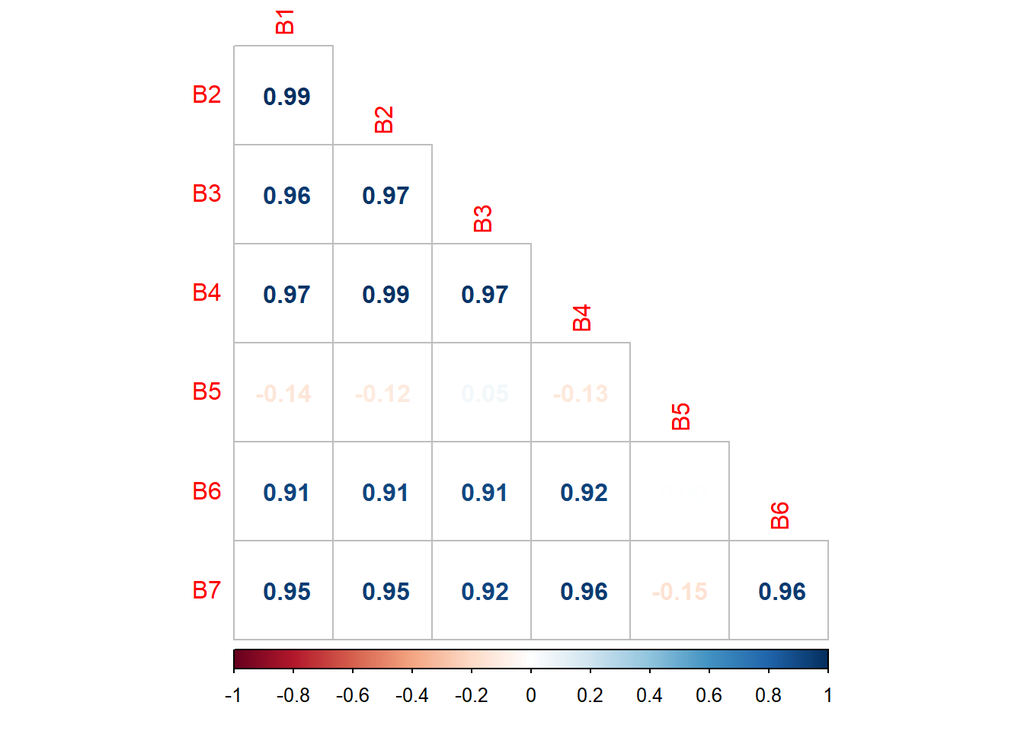

```r
cor_mat = cor(smp, method = "pearson")
corrplot(cor_mat, method = "number", type = "lower", diag = FALSE)
```

# Analiza głównych składowych

Do analizy głównych składowych można wykorzystać między innymi funkcję `prcomp()`. Jeśli dokonaliśmy wcześniej standaryzacji danych, to koniecznie musimy nadać argumentom `scale.` i `center` wartość `FALSE`, aby uniknąć podwójnej standaryzacji.

```r
pca = prcomp(smp, scale. = FALSE, center = FALSE)
summary(pca)
```

```
## Importance of components:
##                           PC1     PC2     PC3     PC4      PC5      PC6
## Standard deviation     0.4242 0.13110 0.02081 0.01448 0.005828 0.003226
## Proportion of Variance 0.9096 0.08688 0.00219 0.00106 0.000170 0.000050
## Cumulative Proportion  0.9096 0.99652 0.99871 0.99977 0.999940 0.999990
##                             PC7
## Standard deviation     0.001162
## Proportion of Variance 0.000010
## Cumulative Proportion  1.000000
```

W podsumowaniu wyników otrzymujemy:

- Odchylenie standardowe (*Standard deviation*) – wskazuje istotność każdej głównej składowej (im większa wartość, tym większa istotność).
- Proporcja wariancji (*Proportion of Variance*) – proporcja całkowitej wariancji wyjaśniona przez każdą główną składową.
- Proporcja skumulowana (*Cumulative Proportion*) – skumulowana część wariancji wyjaśniona przez pierwsze $k$ głównych składowych.

Dodatkowo, otrzymaliśmy dwa obiekty `rotation` i `x`. Ten pierwszy reprezentuje macierz ładunków (*loadings*), natomiast drugi zawiera nowe wartości obserwacji po transformacji rzutowane na główne składowe (można je później wykorzystać do modelowania).

```r
# macierz ładunków PC1 i PC2
pca$rotation[, 1:2]
```

```
##            PC1        PC2
## B1 -0.09808076 -0.1222563
## B2 -0.11679921 -0.1395958
## B3 -0.18303116 -0.1338352
## B4 -0.19240807 -0.2628829
## B5 -0.70912725  0.6855636
## B6 -0.50960658 -0.3565961
## B7 -0.37902046 -0.5304611
```

Ładunki informują, w jakim stopniu każda zmienna wejściowa ma wpływ na każdą główną składową, tzn. wysoka wartość ładunku w pierwszej składowej głównej oznacza, że jest silnie skorelowana z tą składową. Natomiast znak wskazuje kierunek zależności.

Dla przykładu, kanał NIR (B5) ma wysoki ujemny ładunek na pierwszej składowej (PC1), oznacza to, że ta składowa jest silnie zależna od tej zmiennej. Zobaczymy jak wygląda ta zależność wykresie rozrzutu.

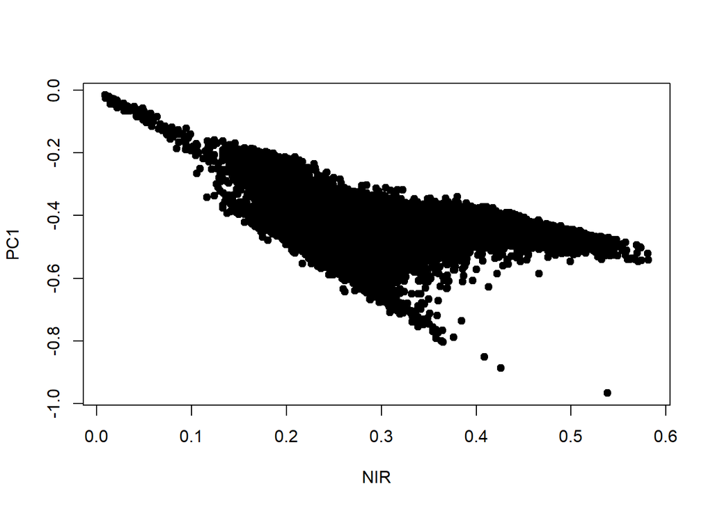

```r
plot(smp$B5, pca$x[, 1], pch = 19, xlab = "NIR", ylab = "PC1")
```

# Interpretacja

Najważniejszym krokiem jest zrozumienie, w jaki sposób interpretować otrzymane wyniki. W tym celu będą pomocne dwa wykresy.

## Wykres piargowy

Wykres piargowy (*scree plot*) to wykres wyjaśnionej wariancji dla każdej głównej składowej. Pomaga określić, ile głównych składowych należy zachować do dalszej analizy. Punkt przegięcia, tzw. “łokieć” wykresu zazwyczaj wskazuje punkt, w którym dodanie większej liczby składowych w niewielkim stopniu przyczynia się do ogólnej wyjaśnionej wariancji. Aby go wyświetlić wystarczy użyć funkcji `plot()` na obiekcie klasy `prcomp`.

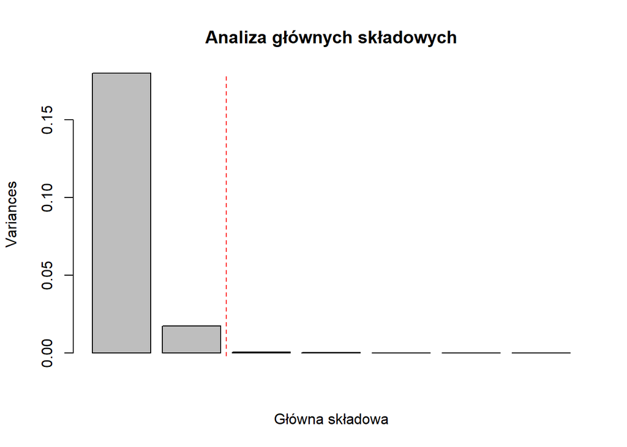

```r
plot(pca, main = "Analiza głównych składowych", xlab = "Główna składowa")
abline(v = 2.5, lty = 2, col = "red")
```

Powyższy wykres sugeruje, że powinniśmy zachować wyłącznie dwie pierwsze główne składowe, które wyjaśniają aż 99% zmienności w danych. Pozostałe składowe reprezentują mniejszą ilość informacji (zasadniczo jest to szum w danych).

## Biplot

Biplot to wykres punktowy przedstawiający rzutowane obserwacje na wybrane główne składowe oraz strzałki reprezentujące ładunki oryginalnych zmiennych, które tworzą pewne kąty. Jeśli wartość kąta pomiędzy strzałkami jest bliska:

- 0° to zmienne są silnie dodatnio skorelowane.
- 180° to zmienne są również silnie skorelowane, ale przeciwnie.
- 90° to zmienne są niezależne (ortogonalne).

Biplot można stworzyć używając funkcji `biplot()` na obiekcie klasy `prcomp`. Argument `choices` pozwoli nam wybrać główne składowe.

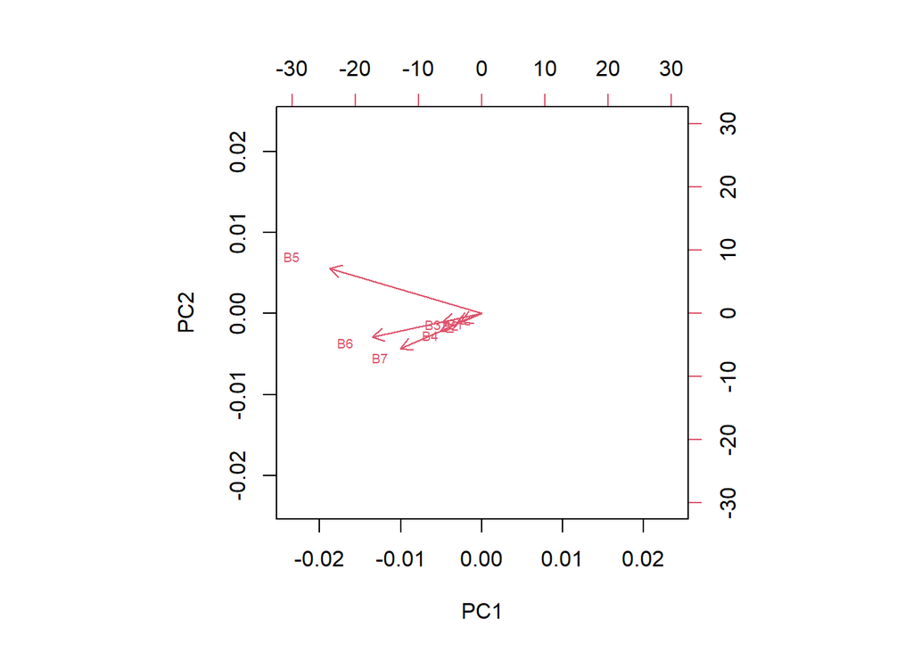

```r
biplot(pca, choices = 1:2, cex = 0.6, xlabs = rep("", nrow(smp)))
```

Niemniej, interpretacja głównych składowych jest skomplikowanym procesem. Z tego powodu warto rozważyć najprostsze techniki redukcji wymiarowości oparte na usuwaniu cechy o bliskiej zeru wariancji (mała zmienność to mało informacji) oraz cech, które są ze sobą silnie skorelowane (np. korelacja powyżej 90%), aby zmniejszyć redundancję danych.

# Predykcja

Po wyznaczeniu głównych składowych, przechodzimy do najtrudniejszego etapu, polegającego na ekstrapolacji wyliczonych głównych składowych z próby na cały raster. Zasadniczo, tę procedurę przeprowadza się sekwencyjnie z podziałem na mniejsze bloki rastra, jednakże nasze rastry są małe i możemy je wczytać całe do pamięci.

Ponownie wykorzystajmy funkcję `as.data.frame()`, aby dokonać konwersji rastrów (`SpatRaster`) do ramki danych. Ustawmy także argument `na.rm = FALSE` do zachowania pustych wartości w rastrze. Następnie, kluczowym krokiem jest wyznaczenie indeksów komórek, które posiadają wartości używając funkcji `complete.cases()`, ponieważ będzie to niezbędne do wstawienia wartości w odpowiednie miejsca w wektorze.

```r
df = as.data.frame(landsat, na.rm = FALSE)
# indeksy komórek z wartościami
idx = complete.cases(df)
# usuń puste wartości
df = df[idx, ]
```

Mamy już przygotowane dane, teraz możemy wykonać ekstrapolację używając funkcji `predict()` i podając dwa wymagane argumenty. Pierwszy to obliczone składowe główne w obiekcie `pca`, a drugi obiekt to ramka danych `df`.

```r
# PCA dla całego zbioru danych
pr = predict(pca, df)
```

Wynikiem powyższej predykcji jest macierz, w której w wierszach znajdują się komórki rastra, a w kolumnach składowe główne. Stwórzmy teraz nowy wektor zawierający wyłącznie brakujące wartości `NA` o takiej długości, ile raster posiada wszystkich komórek (999 * 1240). Następnie używając indeksów z obiektu `idx` przypiszemy wartości pierwszej głównej składowej do wektora `vec` w odpowiednich miejscach.

```r
# stwórz pusty wektor
vec = rep(NA, ncell(landsat))
# przypisz wartości z PC1
vec[idx] = pr[, 1]
```

```r
# stwórz nowy raster
output = rast(landsat, nlyrs = 1, vals = vec)
```

Finalnie, dokonajmy wizualizacji pierwszej głównej składowej (PC1) na mapie.

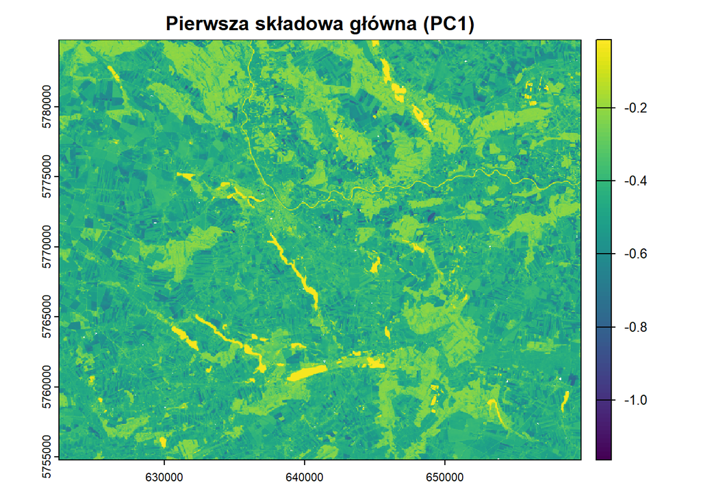

```r
plot(output, main = "Pierwsza składowa główna (PC1)")
```